# R-Studio Tutorial

Student No: 52102609

02/12/2021

Comment: If I have time complete the following - design of document, colour, images. ***

## 1. Introduction

## 2. RMarkdown

### 2.1 RMarkdown File Header

### 2.2 Text and Code Chunks

### 2.3 Headers and Lists in Text Chunks

### 2.4 Inline Code

### 2.5 Output File Type Specification

### 2.6 Generation of Output

## 3. Data Preparation

Before we can start to prepare data we need to complete the follow steps 3.1 - 3.3.

### 3.1 Install the packages

First you want to install the packages you will need to work with the data. I have already installed the packages so for you, you would enter the following code.

Then type in the following code.

**install.packages(tidyverse)**  
**install.packages(here)**

### 3.2 Read the packages into R

```r
# These are the packages we will use to work with the data.
library(tidyverse)
library(here)
```

### 3.3 Read in the data sets

R-Software is case sensitive, so if you name an object with all lower case letters, R will only recognise the name in this form.

```r
demographics<-read_csv(here("2021-12-02_PU5050_Assessment_Input/2021-12-02_PU5050_Demographics.csv"))
ImagingWaitTimes<-read_csv(here("2021-12-02_PU5050_Assessment_Input/2021-12-02_PU5050_ImagingWaitTimes.csv"))
```

### 3.4 Inspect the data

Now that we have the data loaded into R, using the object names demographics and ImagingWaitTimes, we can start to inspect the data. Let’s look at demographics first..

```r
# We will use a function called glimpse to look at the variable names within the data set
glimpse(demographics)
```

```
## Rows: 100
## Columns: 4
## $ chi  <dbl> 2865914370, 7429183650, 2041536789, 6705438219, 9598617423, 47351~
## $ dob  <chr> "04/06/1950", "14/08/1950", "16/03/1951", "11/07/1951", "26/10/19~
## $ sex  <chr> "female", "male", NA, "male", "female", "male", "female", "male",~
## $ city <chr> "Inverness", "Edinburgh", "Dundee", NA, "Glasgow", "Glasgow", "Gl~
```

Another function to look at the data

```r
head(demographics)
```

```
## # A tibble: 6 x 4
##          chi dob        sex    city
##        <dbl> <chr>      <chr>  <chr>
## 1 2865914370 04/06/1950 female Inverness
## 2 7429183650 14/08/1950 male   Edinburgh
## 3 2041536789 16/03/1951 <NA>   Dundee
## 4 6705438219 11/07/1951 male   <NA>
## 5 9598617423 26/10/1951 female Glasgow
## 6 4735162809 18/03/1954 male   Glasgow
```

Again we can see there are 4 groups and the types of data.

Now that we have an understanding of the variable names and type of variables we need to look in more detail for missing values, NA, and any unusual data values.

I’m going to show you first of all how to find the number of missing values in a single column.

```r
demographics%>%
  filter(is.na(dob))%>%
summarise(n())
```

```
## # A tibble: 1 x 1
##   `n()`
##   <int>
## 1     2
```

This shows that within the column dob there are 2 missing values. We want to remove these and save the results to a new object. Let’s call the filtered data filtered_dob.

```r
filtered_dob<-demographics%>%
  filter(!is.na(dob))%>%
  view()
```

If we now check how many missing values there are in the dob column in filtered_dob.

```r
filtered_dob%>%
  filter(is.na(dob))%>%
  summarise(n())
```

```
## # A tibble: 1 x 1
##   `n()`
##   <int>
## 1     0
```

We can see now that the missing values have been removed within the new filtered data. Now if we were to continue with this method we would have to work our way along one column at a time. We would check for the number of missing values, save the new filtered data to a new object, remove the missing values and finally check the values have been removed. However, there is a way we can check all the columns at the same time.

```r
demographics%>%
  summarise_all(~sum(is.na(.)))
```

```
## # A tibble: 1 x 4
##     chi   dob   sex  city
##   <int> <int> <int> <int>
## 1     0     2     2     2
```

We have looked at the original demographics file and we can see there are 2 missing values in the columns dob, sex and city. Let’s remove them and call the new object demo_filter

```r
demo_filter<-demographics%>%
  na.omit()%>%
view()
```

Let’s check that all the missing values have been removed.

```r
#Remember the name of the new filtered data is demo_filter
demo_filter%>%
  summarise_all(~sum(is.na(.)))
```

```
## # A tibble: 1 x 4
##     chi   dob   sex  city
##   <int> <int> <int> <int>
## 1     0     0     0     0
```

We can see that all of the missing values have been removed.

Now we need to look for any unusual values within the data. As we mentioned earlier the dob variable is a character. We will first change this to a date variable.

```r
#The new filtered data is demo_filter
demo_date<-demo_filter%>%
  mutate(dob=as.Date(dob,format("%d/%m/%Y")))%>%
  view()
```

Now I will find the youngest and oldest person in the demo_date.

```r
#Youngest person
demo_date%>%
  summarise(min(dob))
```

```
## # A tibble: 1 x 1
##   `min(dob)`
##   <date>
## 1 1950-06-04
```

```r
#Oldest person
demo_date%>%
  summarise(max(dob))
```

```
## # A tibble: 1 x 1
##   `max(dob)`
##   <date>
## 1 2050-10-11
```

Now unless this person has traveled back in time, you can see there is an error with this date of birth.

This row will need to be removed from demo_date.

```r
# Filtered for dob before today's date
demo_date_filter<-demo_date%>%
  filter(dob<"2021-12-11")%>%
  view()
```

Our filtered data is now ready to be saved as a csv file

```r
write_csv(demo_date_filter,"2021-12-11_PU5050_Demo_Filtered.csv")
```

We are now going to look at the ImagingWaitTimes data.

```r
#Let's use the glimpse function that we used to inspect the demographics data
glimpse(ImagingWaitTimes)
```

```
## Rows: 100
## Columns: 5
## $ chi                       <dbl> 7154809632, 5986237140, 1520976843, 85623409~
## $ month                     <chr> "August", "September", "October", "August", ~
## $ DiagnosticTestType        <chr> "Imaging", "Imaging", "Imaging", "Imaging", ~
## $ DiagnosticTestDescription <chr> "Non-obstetric Ultrasound", "Computer Tomogr~
## $ WaitingDays               <dbl> 63, 60, 53, 35, 56, 44, 60, 31, 63, 62, 35, ~
```

We can see there are 5 columns, with variables, chi, month, DiagnosticTestType, DiagnosticTestDescription and WaitingDays.

```r
# The summary function will find the minimum, 1st Quartile, median, mean, 3rd quartile and maximum value for each varible.
summary(ImagingWaitTimes)
```

```
##       chi               month           DiagnosticTestType
##  Min.   :1.236e+09   Length:100         Length:100
##  1st Qu.:4.328e+09   Class :character   Class :character
##  Median :6.303e+09   Mode  :character   Mode  :character
##  Mean   :5.840e+09
##  3rd Qu.:7.350e+09
##  Max.   :9.841e+09
##  DiagnosticTestDescription  WaitingDays
##  Length:100                Min.   :    -50
##  Class :character          1st Qu.:     33
##  Mode  :character          Median :     44
##                            Mean   :  32722
##                            3rd Qu.:     55
##                            Max.   :3267890
```

This function will provide more insight to numeric variables, but it shows you another way that you can quickly get a feel for the data in your dataset. We are particulary interested in the variable WaitingDays. You can see that the minimum number of days is -50. This is obviously an error and will need to be removed. Notice the maximum value is 3267890. We would hope people are not having to wait 8953.1 years for an imaging appointment! This will aslo have to be removed.

```r
ImagWaitTimesFilter<-ImagingWaitTimes%>%
  filter(WaitingDays>0 & WaitingDays<100)%>%
  view()
```

```r
ImagWaitTimesFilter%>%
  summarise_all(~sum(is.na(.)))%>%
   view()
```

```r
WaitTime_Tidy<-ImagWaitTimesFilter%>%
  na.omit()%>%
  view()
```

```r
WaitTime_Tidy%>%
summarise_all(~sum(is.na(.)))
```

```
## # A tibble: 1 x 5
##     chi month DiagnosticTestType DiagnosticTestDescription WaitingDays
##   <int> <int>              <int>                     <int>       <int>
## 1     0     0                  0                         0           0
```

The WaitTime_Tidy data has now been filtered for unusual values and the rows with missing values has been removed. We are now ready to save the sorted data.

```r
write_csv(WaitTime_Tidy,"2021-12-12_PU5050_WaitTime_Tidy.csv")
```

We are now read to join the data sets. There are many ways to join datasets. You have to have a good understanding of the data and how you want it to join. In our scenario we want all of the waiting time details matched with the corresponding chi number from the demo_date_filter data.

```r
join_demo_wait <- inner_join(WaitTime_Tidy,demo_date_filter, by = "chi")%>%
view()
# There are still two NA values in ImagWaitTimesFilter
```

```r
# Check the NA values again once the issue has been fixed!!!
join_demo_wait%>%
  summarise_all(~sum(is.na(.)))
```

```
## # A tibble: 1 x 8
##     chi month DiagnosticTestTy~ DiagnosticTestDes~ WaitingDays   dob   sex  city
##   <int> <int>             <int>              <int>       <int> <int> <int> <int>
## 1     0     0                 0                  0           0     0     0     0
```

## 4. Data Visualisation

We are now ready to answer the question: What is the average number of Waiting Days, in each Scottish city, in October 2021?

The first thing to do is to decide what data it is we need to answer the question. We need the month, DiagnosticTestDescription, WaitingDays and City.

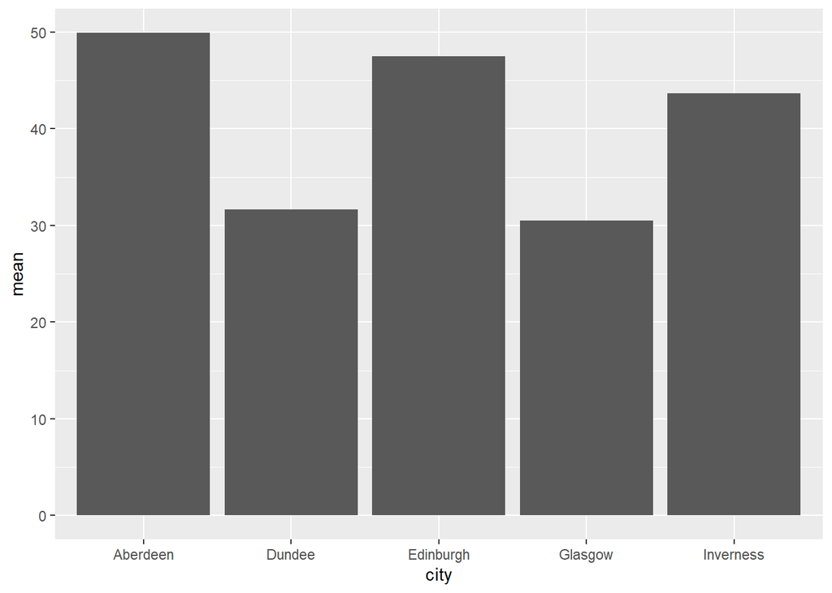

```r
#still got to remove the missing values
join_demo_wait%>%
  select(month,DiagnosticTestDescription,WaitingDays,city)%>%
  filter(DiagnosticTestDescription=="Computer Tomography")%>%
  filter(month=="October")%>%
  group_by(city)%>%
    mutate(mean=mean(WaitingDays))%>%
  select(city,mean)%>%
unique()%>%
ggplot()+
geom_col(aes(city,mean))
```

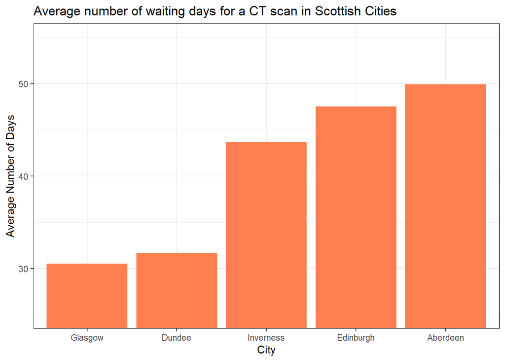

```r
join_demo_wait%>%
  select(month,DiagnosticTestDescription,WaitingDays,city)%>%
  filter(DiagnosticTestDescription=="Computer Tomography")%>%
  filter(month=="October")%>%
  group_by(city)%>%
    mutate(mean=mean(WaitingDays))%>%
  select(city,mean)%>%
unique()%>%

ggplot(aes(fct_reorder(city,mean),mean))+
geom_col(fill="coral")+
   labs(x="City",y="Average Number of Days", title = "Average number of waiting days for a CT scan in Scottish Cities")+
  coord_cartesian(ylim=c(25,55))+
  theme_bw()
```

1. Data
2. Facets
3. Mapping
4. Scales
5. Coords
6. Geoms
7. Stats  
   Themes

## 5. Summary and Reflection

What has been your experience using R for reproducible data analysis?

I found it challenging at first to understand the very basic concepts, such as, reading in data or how the file structures worked. This lack of understanding limited the reproducibility of my work. I kept revising the basics and gradually I began to improve my R programming skills. I realised very quickly I had to really think ahead about what it was I was trying to achieve. I had to ask myself constant questions;

- How is this dataset formatted?
- What functions can I use?
- Is this the expected outcome and if not, why?

The constant reflection is not enough will to improve the reproducibility, but all of the reflection must be documented for others to follow. This has also been a large challenge for me. The organisation of file structures and logically documenting my work is something I will have to practice.

- Reading lots of theory - really need practice
- Please reflect on any problems or issues you encountered, for example whilst creating and merging datasets, or using the R language.
  - Over thinking the basics
  - Not focusing on what I expect to happen
  - Not having a logical plan
  - Had to slow down
  - Couldn’t visualise how everything connected ie branches
  - RNotebook